# AZ Coronavirus Most Recent Month

To see all data from mid-march, see this view

## Total Testing

### Total testing trend

This is how many tests we are conducting a day, with the line being a 7-day running average. The trend here helps determine if we are increasing, decreasing or maintaining the same testing volume. The 2nd axis on the right shows the testing as a percentage of Arizona’s population.

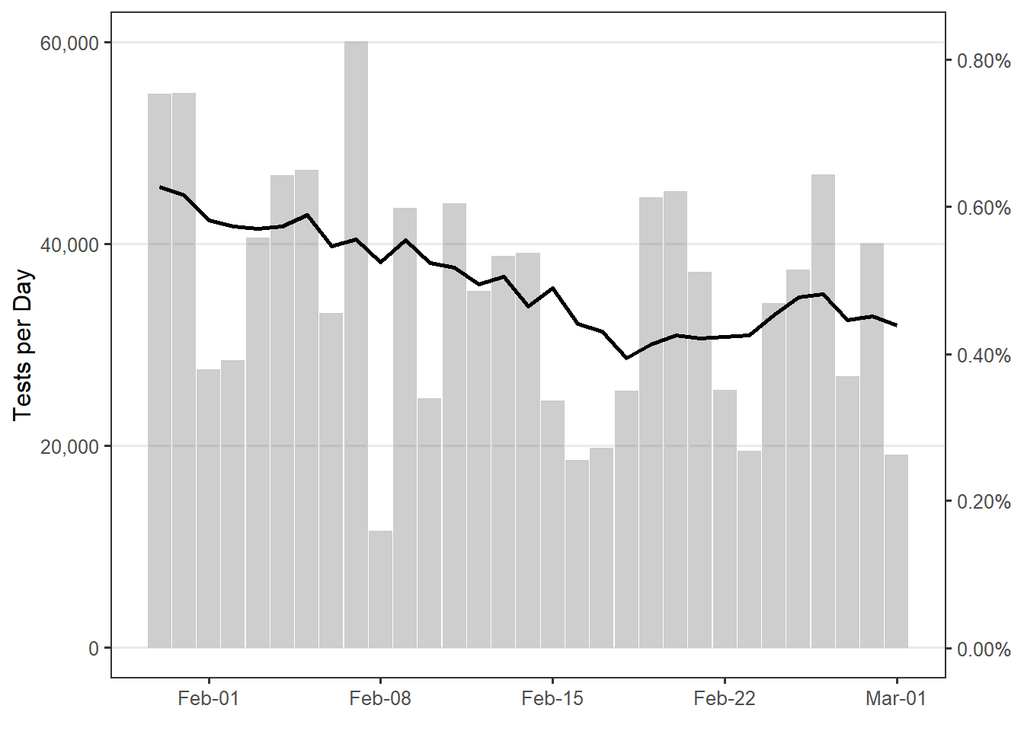

### Total tests per capita

This shows how many total tests we have conducted per capita. The goal of this is to get a sense of what percentage of Arizona’s population may have been tested. Please note that people may be tested multiple times, so the percentage of population that has been tested will likely be lower than what is shown.

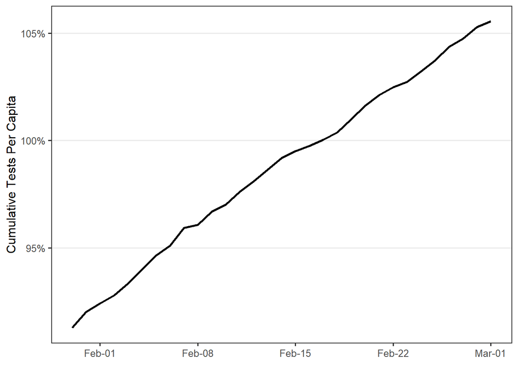

## Positive Tests

### Positive Testing Trend

How many tests are returning positive per day. The line is a 7-day running average. It’s important to contextualize this with changes in total testing and changes in how many tests are returning positive.

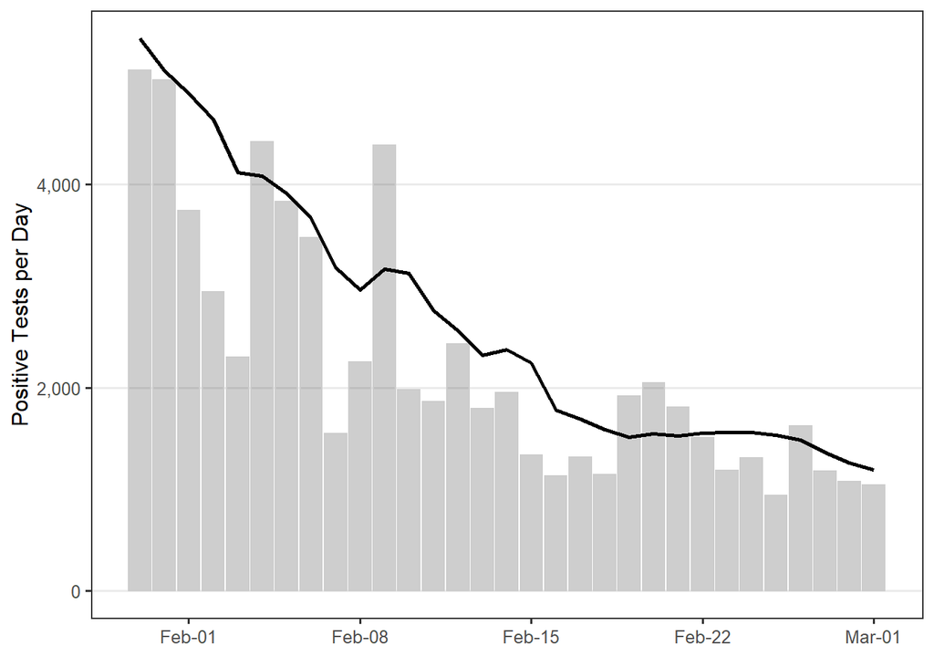

### Positive test percentage

This is what percentage of daily tests are returning positive. A positive trend means more of our testing is identified infected individuals. The line is a 7-day weighted running average.

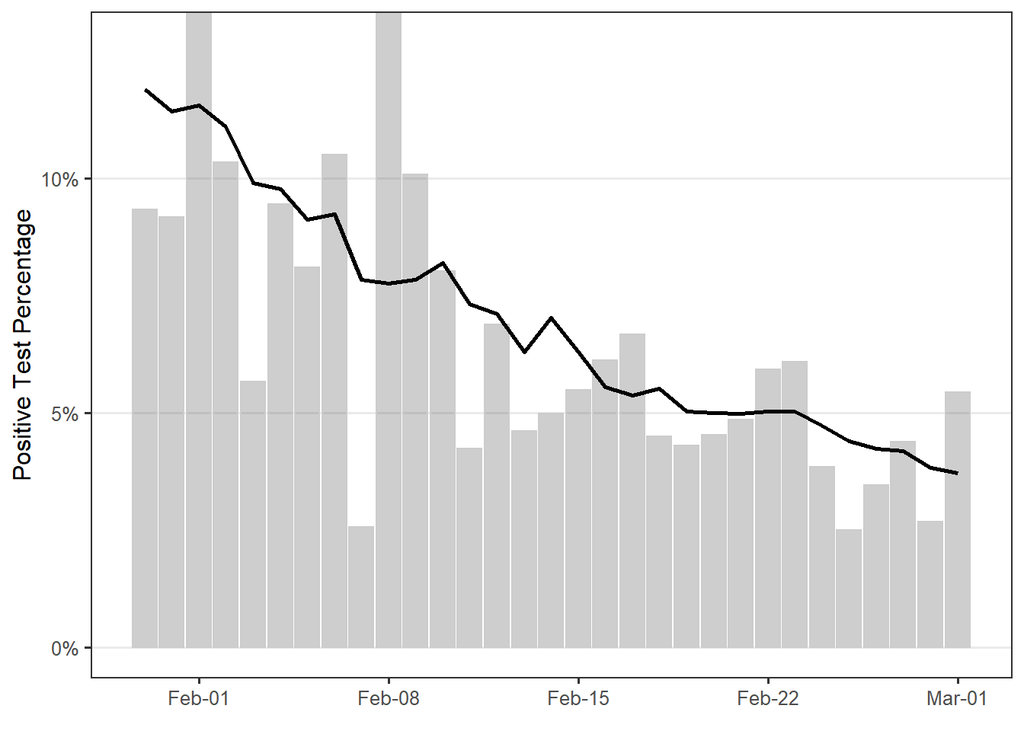

## Medical Care

### Hospitalizations Trend

This shows the daily change in hospitalizations. This includes (to my knowledge) both admittances and discharges. A positive trend would likely indicate an increase in severe cases, though could possibly indicate an increase in stay length. The line is a 7-day running average

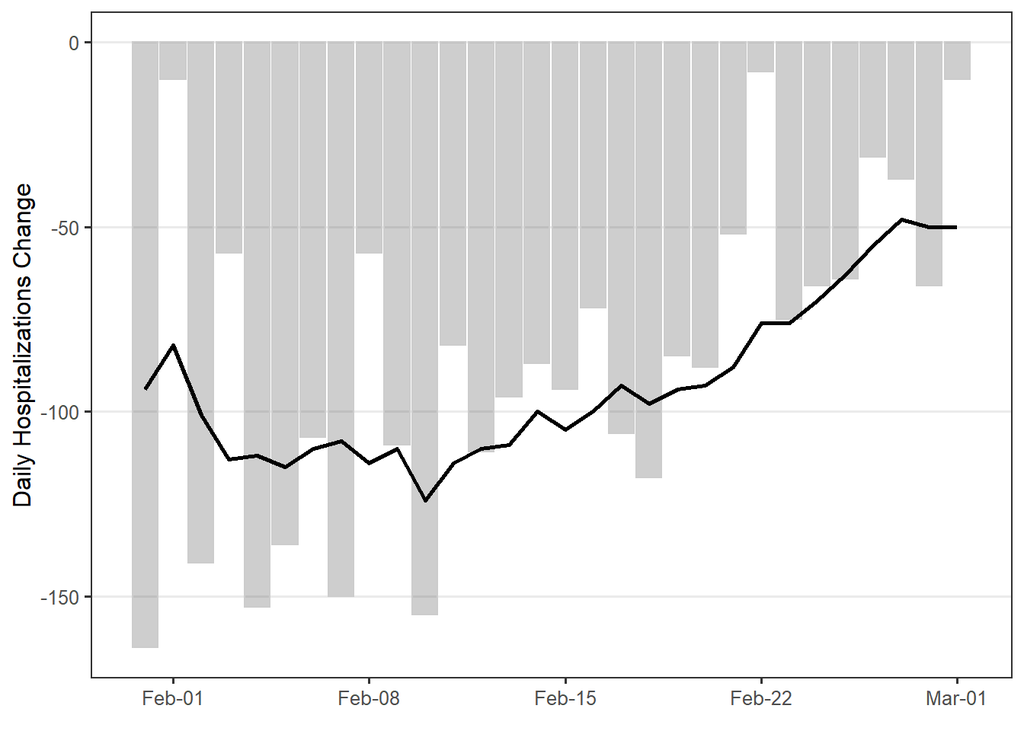

### Deaths

This is how many deaths have been reported each day. The line is a 7-day running average

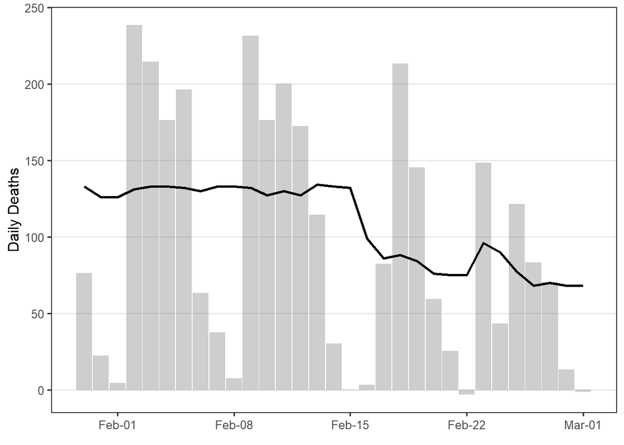

### Hospital Occupancy

This is how many hospital beds are devoted to caring for Coronavirus patients. The line is a 7-day running average.

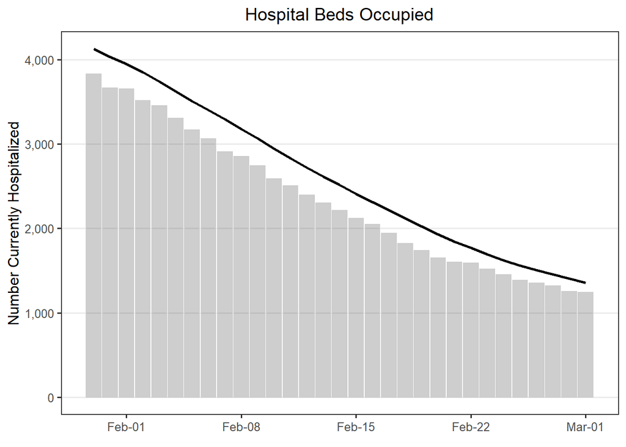

### ICU Occupancy

This is how many Coronavirus patients are in the ICU. The line is a 7-day running average.

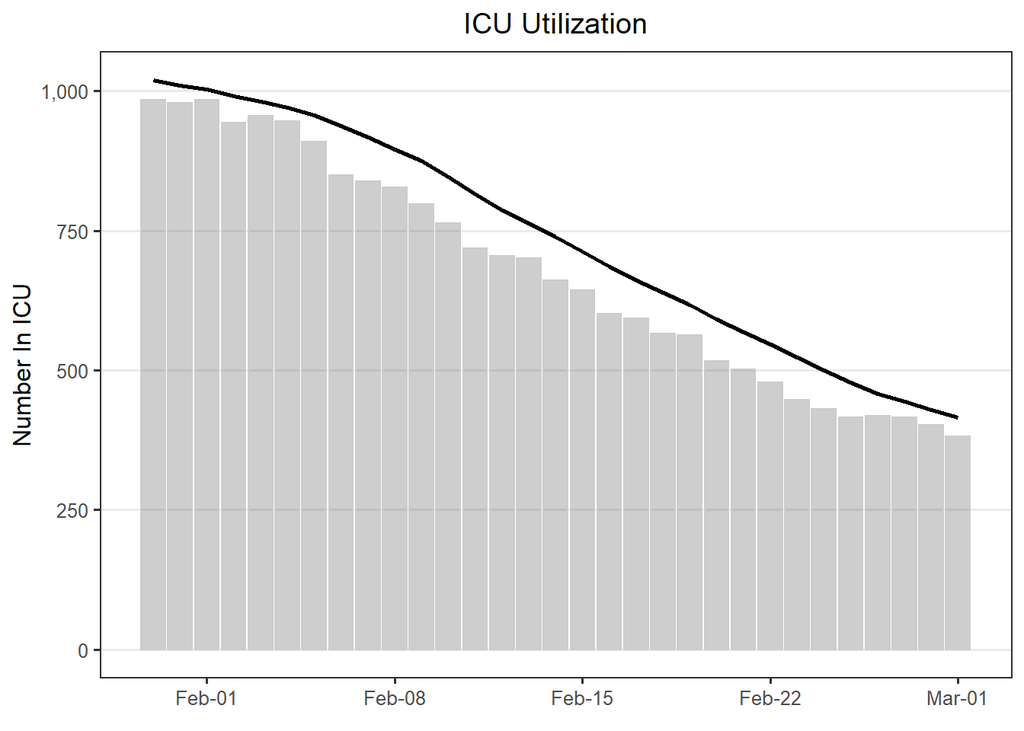

### Ventilator Usage

This is how many Ventilators are currently being used. The line is a 7-day running average.

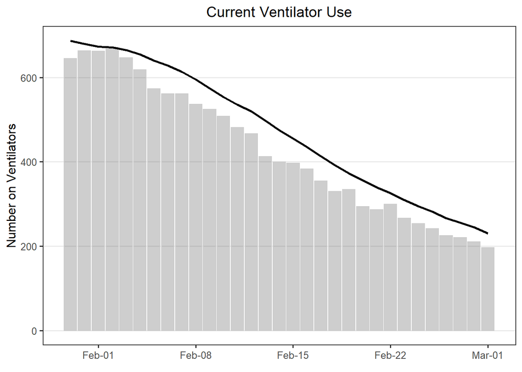